# Blood Composition

April 2, 2015

### Summary

- Whole blood is a heterogeneous collection of different cell types
  - Lymphcytes, Monocytes, Granulocytes.
- Each type has a very different DNAm profile
  - large between cell type differences
- Cellular composition explains much of the observed variability in DNA methylation
  - need to be ajusted for if confounding with covariate of interest.
- Cellular composition correlates strongly with global DNAm profiless
  - High correlation between DNAm variance and composition variance : [PCA biplot](http://genomebiology.com/2014/15/2/R31/figure/F3)
- [Jaffe et al.2014](http://genomebiology.com/2014/15/2/R31)

## Age related findings

- Strong evidence of cell composition change across age in blood.
- High levels confounding between age related variability and cellular composition at the CPG level
- Cell type proportions changes with age following monotonic patterns
- Confounding between cell composition and age leads to false positives

## Algorithm

- first designed for Illumina 27K Chip by [Houseman et al.](http://www.biomedcentral.com/1471-2105/13/86) (2012)
  - identified 500 CpGs that discriminated cellular composition in flow-sorted cell populations
  - fites a nonlinear random effects model at each of these CpGs
  - estimate the coefficient for each cellular component
  - use these coeficeints to predict the relative proportions of each cellular components
- modified by Jaffe et al (2014)
  - using linear modeling across 600 composition -discriminating probes.
  - implemented in R - minfi Bioconducto package
  - CD4+, CD8+, NK, B cells, Monocytes, Granulocytes

## PHQchange vs each Cell Type at Visit 1 (n = 65)

```
Loading required package: grid
```

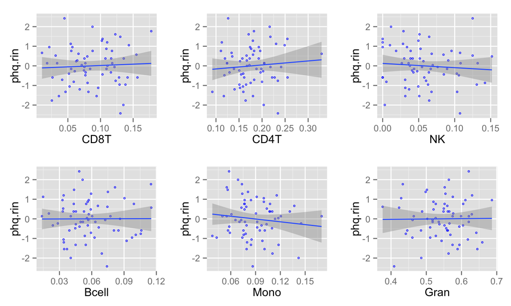

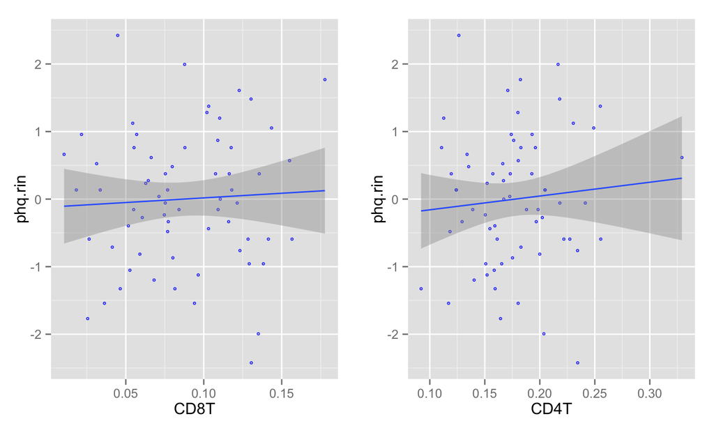

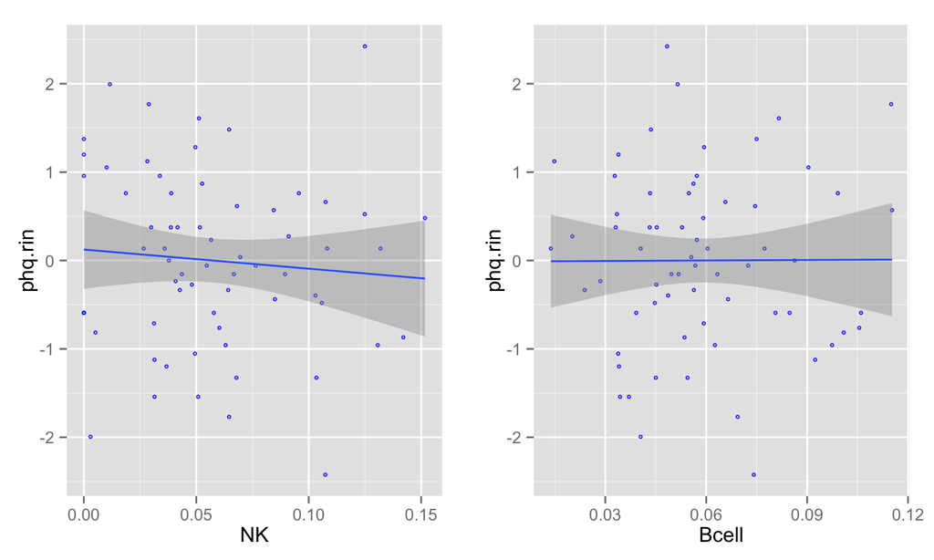

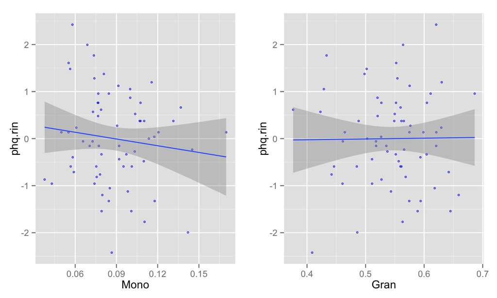

## Scatter Plot: Cell Type v1 vs v2

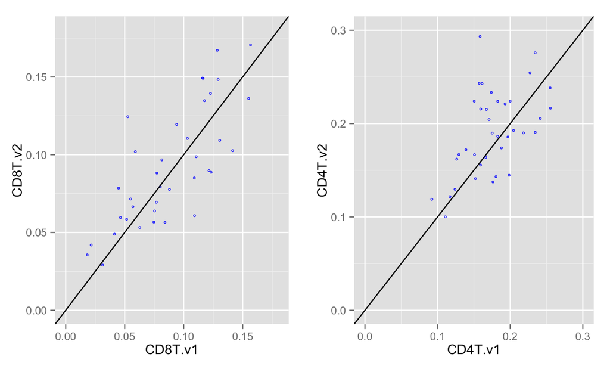

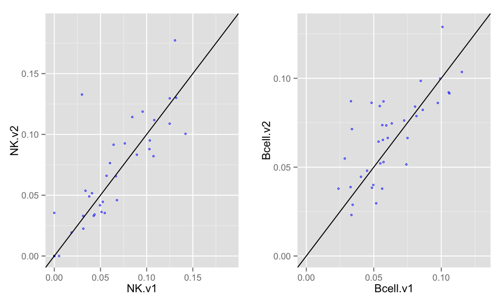

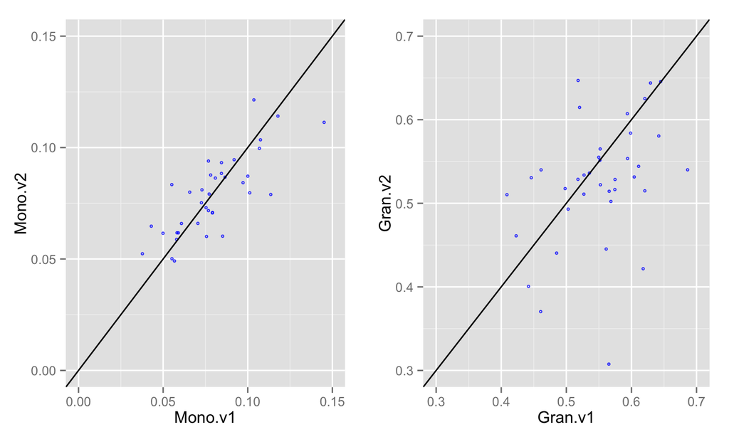

## Histograms: Cell Type v1 vs v2

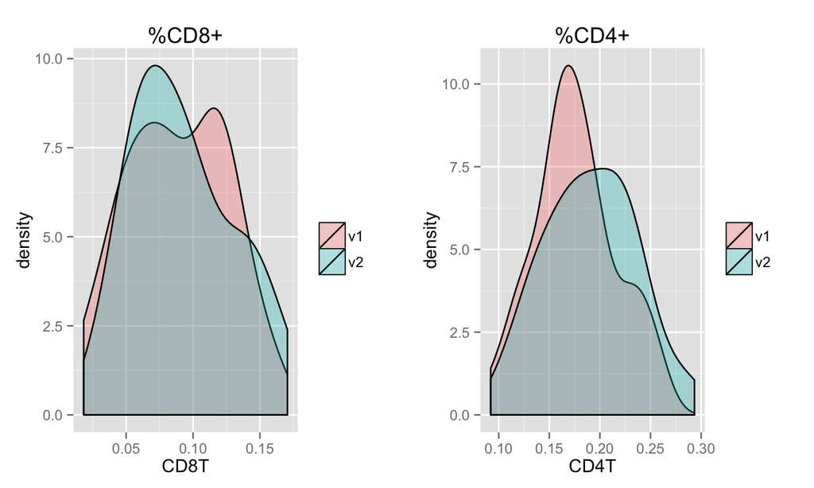

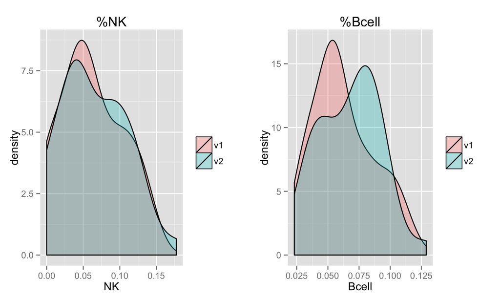

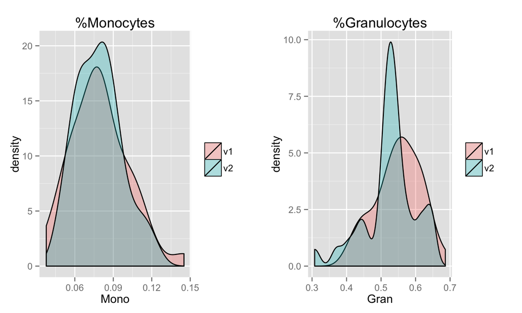